# 2. Matplotlib基礎_Q slides

## Matplotlib 基礎

### Da-Wei Chiang

## 大綱

- 安裝
- 折線圖
- 散布圖
- 綜合應用 - 三角函數
- 中文字設定

## 安裝

```
pip install matplotlib

conda install matplotlib
```

## 折線圖

```
import matplotlib.pyplot

plot(x, y, lw, ls, label, color)

# x : x軸值
# y : y軸值
# lw : 線條寬度（line width）
# ls : 線條樣式（line style）
# label : 圖表標籤
# color : 線條顏色
```

```
x =  [0, 1, 2, 3, 4, 5, 6, 7, 8, 9]
y =  [7, 7, 10, 1, 2, 9, 7, 1, 1, 2]
```

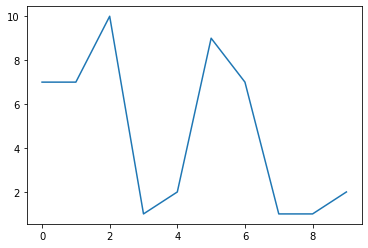

```python
## 範例

import matplotlib.pyplot as plt

x = [i for i in range(10)]
y = [7, 7, 10, 1, 2, 9, 7, 1, 1, 2]
print("x = ", x)
print("y = ", y)
plt.plot(x, y)
plt.show()
```

```
y :  [7, 7, 10, 1, 2, 9, 7, 1, 1, 2]
```

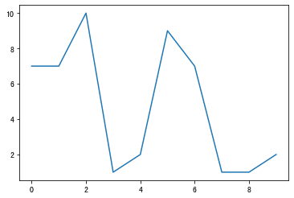

```python
## 範例

import matplotlib.pyplot as plt

y = [7, 7, 10, 1, 2, 9, 7, 1, 1, 2]
print("y : ", y)
plt.plot(y)
plt.show()
```

## 練習

- 請隨機產生10個數（介於1~20之間）
- 撰寫一個匿名函數, 將這10個數進行平方
- 請繪製這10個數值的折線圖

## 設定線條顏色

- 於`plot`方法中增加`color`參數設定

```
y :  [7, 7, 10, 1, 2, 9, 7, 1, 1, 2]
```

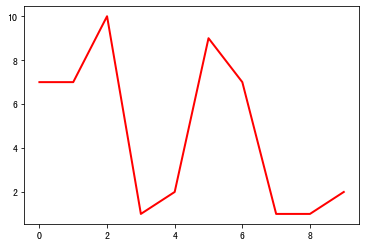

```python
## 範例

import matplotlib.pyplot as plt

y = [7, 7, 10, 1, 2, 9, 7, 1, 1, 2]
print("y : ", y)
plt.plot(y, color='red')
plt.show()
```

## 各類顏色縮寫

```
b : 藍色
c : 青色
g : 綠色
k : 黑色
r : 紅色
w : 白色
y : 黃色
```

```
y :  [7, 7, 10, 1, 2, 9, 7, 1, 1, 2]
```

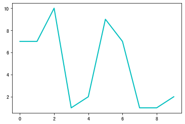

```python
## 範例

import matplotlib.pyplot as plt

y = [7, 7, 10, 1, 2, 9, 7, 1, 1, 2]
print("y : ", y)
plt.plot(y, 'c')   #color參數名稱可不寫
plt.show()
```

## 自定義色碼

```
plt.plot(data, '16進制色碼')  #16進制色彩設定

plt.plot(data, color=(R/255, G/255, B/255))  #RGB色碼設定, color屬性名稱不可省略

plt.plot(data, color=(R/255, G/255, B/255, A))  #A為透明度設定, 範圍介於0~1
```

```
y :  [7, 7, 10, 1, 2, 9, 7, 1, 1, 2]
```

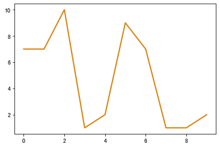

```python
## 範例 - 16進制設定

import matplotlib.pyplot as plt

y = [7, 7, 10, 1, 2, 9, 7, 1, 1, 2]
print("y : ", y)
plt.plot(y, '#DB810B')
plt.show()
```

```
y :  [7, 7, 10, 1, 2, 9, 7, 1, 1, 2]
```

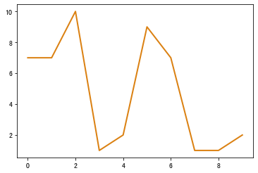

```python
## 範例 - RGB設定

import matplotlib.pyplot as plt

y = [7, 7, 10, 1, 2, 9, 7, 1, 1, 2]
print("y : ", y)
plt.plot(y, color=((219/255, 129/255, 11/155)))
plt.show()
```

```
y :  [7, 7, 10, 1, 2, 9, 7, 1, 1, 2]
```

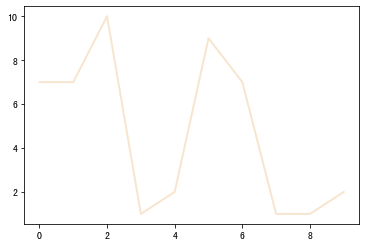

```python
## 範例 - RGBA設定

import matplotlib.pyplot as plt

y = [7, 7, 10, 1, 2, 9, 7, 1, 1, 2]
print("y : ", y)
plt.plot(y, color=((219/255, 129/255, 11/155, 0.2)))
plt.show()
```

## 練習

- 請自行練習變更線條顏色

## 設定軸線

```
## 設定軸線
axis([x軸起點, x軸終點, y軸起點, y軸終點])

## 查看軸線值
xmin_Variable, xmax_Variable, ymin_Variable, ymax_Variable = plt.axis()
```

```
y :  [7, 2, 3, 2, 1, 3, 2, 9, 2, 4]
x min = -0.45
x max = 9.45
y min = 0.6
y max = 9.4
```

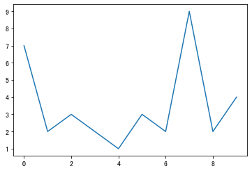

```
x min = 0.0
x max = 10.0
y min = 0.0
y max = 10.0
```

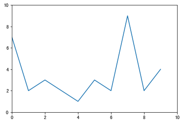

```python
## 範例

import matplotlib.pyplot as plt
import random

y = [random.randint(1, 10) for i in range(10)]
print("y : ", y)
plt.plot(y)
x_min, x_max, y_min, y_max = plt.axis()
print('x min =', x_min)
print('x max =', x_max)
print('y min =', y_min)
print('y max =', y_max)
plt.show()
plt.plot(y)
plt.axis([0, 10, 0, 10])
x_min, x_max, y_min, y_max = plt.axis()
print('x min =', x_min)
print('x max =', x_max)
print('y min =', y_min)
print('y max =', y_max)
plt.show()
```

## 單設定`x`或單設定`y`

```
## 單設定x軸: 一起設定
plt.xlim(x軸起點, x軸終點)
## 單設定x軸: 分開設定
plt.xlim(x軸起點)
plt.xlim(x軸終點)

## 單設定y軸: 一起設定
plt.ylim(y軸起點, y軸終點)
## 單設定y軸: 分開設定
plt.ylim(y軸起點)
plt.ylim(y軸終點)

## 取得x軸設定
xmin_Variable, xmax_Variable = plt.xlim()
## 取得y軸設定
ymin_Variable, ymax_Variable = plt.ylim()
```

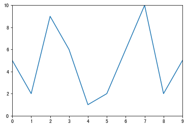

```python
## 範例

x =  [0, 1, 2, 3, 4, 5, 6, 7, 8, 9]
y =  [5, 2, 9, 6, 1, 2, 6, 10, 2, 5]
plt.xlim(0, 9)
plt.ylim(0, 10)
plt.plot(x, y)
plt.show()
```

## 練習

- 請自行練習軸線設定

## 繪製格線

```
plt.grid()
```

```
y :  [8, 1, 5, 2, 1, 1, 6, 2, 3, 5]
```

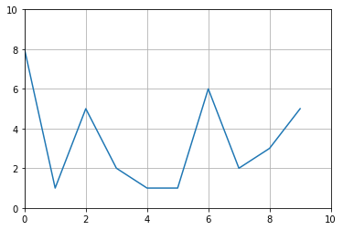

```python
## 範例

import matplotlib.pyplot as plt
import random

y = [random.randint(1, 10) for i in range(10)]
print("y : ", y)
plt.plot(y)
plt.grid()
plt.axis([0, 10, 0, 10])
plt.show()
```

## 設定線條寬度 - 方法一

```
plot(x, y, lw)
```

```
y :  [6, 1, 8, 1, 8, 8, 6, 10, 4, 8]
```

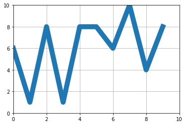

```python
## 範例

import matplotlib.pyplot as plt
import random

y = [random.randint(1, 10) for i in range(10)]
print("y : ", y)
plt.plot(y, lw=10)
plt.grid()
plt.axis([0, 10, 0, 10])
plt.show()
```

## 設定線條寬度 - 方法二

- 透過`rcParams`參數設定, 設定方式如下

```
plt.rcParams['lines.linewidth'] = number


## 注意 - 透過rcParams設定後的參數值會每次繪圖都套用
```

```
y :  [6, 1, 8, 1, 8, 8, 6, 10, 4, 8]
```

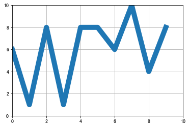

```python
## 範例

import matplotlib.pyplot as plt
import random

y = [6, 1, 8, 1, 8, 8, 6, 10, 4, 8]
print("y : ", y)
plt.rcParams['lines.linewidth'] = 10
plt.plot(y)
plt.grid()
plt.axis([0, 10, 0, 10])
plt.show()
```

## 設定標題

```
title(名稱, fontsize=數字)
xlabel(名稱, fontsize=數字)
ylabel(名稱, fontsize=數字)
```

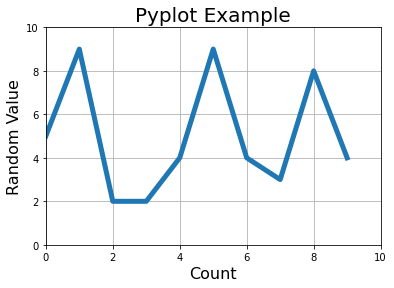

```python
## 範例
import matplotlib.pyplot as plt
import random

y = [random.randint(1, 10) for i in range(10)]
plt.plot(y, lw=5)
plt.title("Pyplot Example", fontsize=20)
plt.xlabel("Count", fontsize=16)
plt.ylabel("Random Value", fontsize=16)
plt.axis([0, 10, 0, 10])
plt.grid()
plt.show()
```

## 設定刻度樣式

```
tick_params(axis='參數', labelsize=數字, color='顏色')

axis：both(表示x軸及y軸)、xx(表示x軸)、yy(表示y軸)
labelsize：刻度字體大小
color：刻度顏色
```

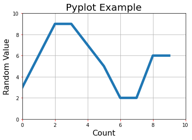

```python
## 範例
import matplotlib.pyplot as plt
import random

y = [random.randint(1, 10) for i in range(10)]
plt.plot(y, lw=5)
plt.title("Pyplot Example", fontsize=20)
plt.xlabel("Count", fontsize=16)
plt.ylabel("Random Value", fontsize=16)
plt.axis([0, 10, 0, 10])
plt.grid()
plt.tick_params(axis='both', labelsize=10, color='red')
plt.show()
```

## 練習

```
有個方程式如下
y = 4x+3
請繪製x為1~10時y值的折線圖

請設定折線圖名稱、x軸標籤、y軸標籤、格線、線條顏色設為紅色、線條寬度為10、座標0對準起始點
```

## 多組數據設定

```
plot(xdata, ydata, xdata, ydata...)
```

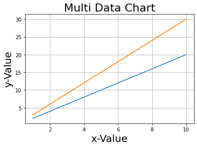

```python
## 範例

import matplotlib.pyplot as plt

data1 = [(i*2) for i in range(1, 11)]
data2 = [(i*3) for i in range(1, 11)]
y = [i for i in range(1, 11)]
plt.plot(y, data1, y, data2)
plt.title("Multi Data Chart", fontsize=22)
plt.ylabel("y-Value", fontsize=20)
plt.xlabel("x-Value", fontsize=20)
plt.grid()
plt.show()
```

## 線條樣式設定

- 線條顏色設定

  ```
    'b' : blue
    'c' : cyan
    'g' : green
    'k' : black
    'r' : red
    'w' : white
    'y' : yellow
    ...
  ```

- 線條樣式設定

  ```
    '-' : solid (預設)
    '--' : dashed
    '-.' : dashdot
    ':' : dotted
    ...
  ```

- 資料點樣式設定

  ```
    '.' : 點
    'o' : 圓
    '^' : 三角
    's' : 方形
    '*' : 星形
    '+' : 加號
    '-' : 減號
    ...
  ```

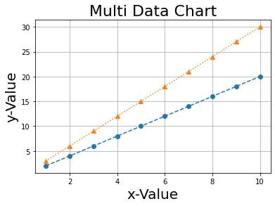

```python
## 範例

import matplotlib.pyplot as plt

data1 = [(i*2) for i in range(1, 11)]
data2 = [(i*3) for i in range(1, 11)]
y = [i for i in range(1, 11)]
plt.plot(y, data1, '--o', y, data2, ':^')
plt.title("Multi Data Chart", fontsize=22)
plt.ylabel("y-Value", fontsize=20)
plt.xlabel("x-Value", fontsize=20)
plt.grid()
plt.show()
```

## 練習

```
有三組數據分別如下
    1. 數據一：1, 2, 3, 4, 5 ...共20個數
    2. 數據二：1, 4, 9, 16, 25 ...共20個數
    3. 數據三：1, 3, 6, 10, 15 ...共20個數
請繪製折線圖
    數據一資料點為圓形、數據二資料點為方形、數據三資料點為星形
    數據一資料線為實現、數據二資料線為虛線、數據三資料線為點虛線
    整體圖形設定
        繪製網格
        起始點(0, 0)由左下角開始
        設定圖表名稱為Practice Chart, 字體大小20
        設定x軸名稱為Data Count, 字體大小18
        設定y軸名稱為Value, 字體大小18
```

## 練習

```
各國2018~2020平均月薪如下

台灣：40980, 41883, 42980
日本：87830, 92800, 91245
韓國：82083, 83452, 86521

樣式設定：
    台灣資料點為圓形、線為實線;日本資料點為三角形、線為虛線;韓國資料點為方形、線為點線
    設定圖片名稱為Average Salary, 字體大小20
    設定x軸名稱為Year, 字體大小18
    設定y軸名稱為Salary, 字體大小18
```

## 刻度設計

```
xticks() #設定x軸刻度
yticks() #設定y軸刻度
```

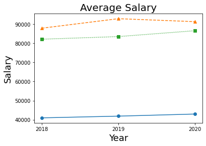

```python
## 範例

import matplotlib.pyplot as plt

year = [2018, 2019, 2020]
Taiwan = [40980, 41883, 42980]
Japan = [87830, 92800, 91245]
Korea = [82083, 83452, 86521]

plt.plot(year, Taiwan, 'o-', year, Japan, '^--', year, Korea, 's:')
plt.title('Average Salary', fontsize=20)
plt.xticks(year)
plt.xlabel('Year', fontsize=18)
plt.ylabel('Salary', fontsize=18)
plt.show()
```

## 圖例

```
legend(loc='0~10', bbox_to_anchor=(number,number), title="~")

loc :
    best = 0
    upper right = 1
    upper left = 2
    lower left = 3
    lower right = 4
    right = 5
    center left = 6
    center right = 7
    lower center = 8
    upper center = 9
    center = 10
```

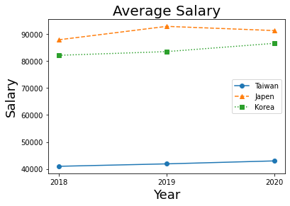

```python
## 範例 - 一般圖例

import matplotlib.pyplot as plt

year = [2018, 2019, 2020]
Taiwan = [40980, 41883, 42980]
Japan = [87830, 92800, 91245]
Korea = [82083, 83452, 86521]

#plt.plot(year, Taiwan, 'o-', year, Japan, '^--', year, Korea, 's:')
plt.plot(year, Taiwan, 'o-', label='Taiwan')
plt.plot(year, Japan, '^--', label='Japen')
plt.plot(year, Korea, 's:', label='Korea')
plt.title('Average Salary', fontsize=20)
plt.xticks(year)
plt.xlabel('Year', fontsize=18)
plt.ylabel('Salary', fontsize=18)
plt.legend(loc='best')
plt.show()
```

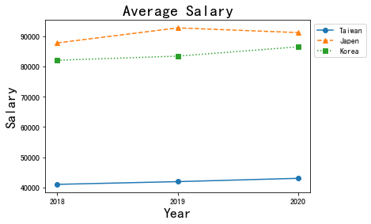

```python
## 範例 - 圖外圖例

import matplotlib.pyplot as plt

year = [2018, 2019, 2020]
Taiwan = [40980, 41883, 42980]
Japan = [87830, 92800, 91245]
Korea = [82083, 83452, 86521]

#plt.plot(year, Taiwan, 'o-', year, Japan, '^--', year, Korea, 's:')
plt.plot(year, Taiwan, 'o-', label='Taiwan')
plt.plot(year, Japan, '^--', label='Japen')
plt.plot(year, Korea, 's:', label='Korea')
plt.title('Average Salary', fontsize=20)
plt.xticks(year)
plt.xlabel('Year', fontsize=18)
plt.ylabel('Salary', fontsize=18)
plt.legend(bbox_to_anchor=(1,1))
plt.show()
```

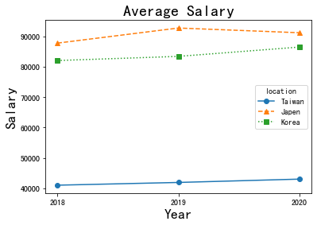

```python
## 範例 - 設定legend title

import matplotlib.pyplot as plt

year = [2018, 2019, 2020]
Taiwan = [40980, 41883, 42980]
Japan = [87830, 92800, 91245]
Korea = [82083, 83452, 86521]

#plt.plot(year, Taiwan, 'o-', year, Japan, '^--', year, Korea, 's:')
plt.plot(year, Taiwan, 'o-', label='Taiwan')
plt.plot(year, Japan, '^--', label='Japen')
plt.plot(year, Korea, 's:', label='Korea')
plt.title('Average Salary', fontsize=20)
plt.xticks(year)
plt.xlabel('Year', fontsize=18)
plt.ylabel('Salary', fontsize=18)
plt.legend(loc='best', title='location')
plt.show()
```

## 儲存圖片

```
savefig('name.jpg', bbox_inches='tight')
```

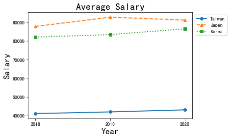

```python
## 範例 - 圖外圖例

import matplotlib.pyplot as plt

year = [2018, 2019, 2020]
Taiwan = [40980, 41883, 42980]
Japan = [87830, 92800, 91245]
Korea = [82083, 83452, 86521]

#plt.plot(year, Taiwan, 'o-', year, Japan, '^--', year, Korea, 's:')
plt.plot(year, Taiwan, 'o-', label='Taiwan')
plt.plot(year, Japan, '^--', label='Japen')
plt.plot(year, Korea, 's:', label='Korea')
plt.title('Average Salary', fontsize=20)
plt.xticks(year)
plt.xlabel('Year', fontsize=18)
plt.ylabel('Salary', fontsize=18)
plt.legend(loc='best', bbox_to_anchor=(1,1))
plt.savefig('Salary.jpg', bbox_inches='tight')
plt.show()
```

## 讀取圖片

```
import matplotlib.image as img

image_Variable = img.imread('name.jpg')
plt.imshow(image_Variable)
plt.show()
```

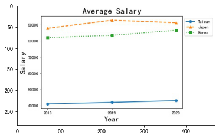

```python
## 範例

import matplotlib.pyplot as plt
import matplotlib.image as img

image = img.imread('Salary.jpg')
plt.imshow(image)
plt.show()
```

```
plt.axis('off')
```

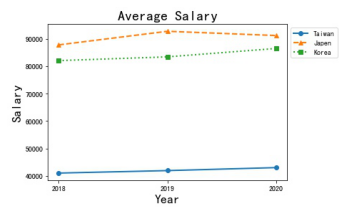

```python
## 範例

import matplotlib.pyplot as plt
import matplotlib.image as img

image = img.imread('Salary.jpg')
plt.imshow(image)
plt.axis('off')
plt.show()
```

## 練習

```
全台2019年與2020年當月最高氣溫資料如下

2019 : 31.5, 33.9, 33.8, 38.9, 35, 37.3, 37.4, 37.8, 36.1, 36.7, 31.8, 30.1
2020 : 29.9, 30.3, 34.6, 34.2, 37.3, 37.6, 40.2, 39.1, 38.2, 35.9, 34.4, 29.8

請繪製氣溫折線圖
並回答以下問題
    兩個年度中，哪個年份、哪個月的溫度最高？
    哪個年度的平均氣溫較高？
```

## 散佈圖

```
import matplotlib.pyplot as plt  # 引用

plt.scatter(x, y, s, c)   #繪圖

參數說明：
    x, y : 在(x, y)的位置繪圖
    s : 點的大小
    c: 點的顏色
```

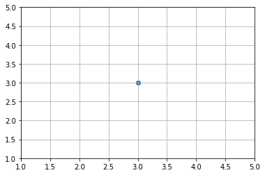

```python
## 範例 - basic

import matplotlib.pyplot as plt

plt.scatter(3,3)
plt.grid()
plt.axis([1, 5, 1, 5])
plt.show()
```

```
[3, 1, 10, 2, 4]
```

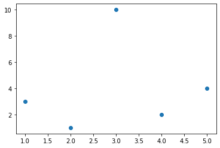

```python
## 範例 - 多個點繪製

import matplotlib.pyplot as plt
import random

xcoor = [1, 2, 3, 4, 5]
ycoor = [random.randint(1, 10) for i in range(5)]
print(ycoor)
plt.scatter(xcoor, ycoor)
plt.show()
```

```
[5, 1, 10, 1, 2]
```

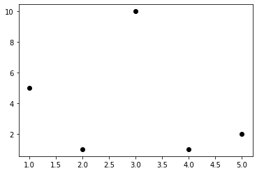

```python
## 範例 - 設定顏色

import matplotlib.pyplot as plt
import random

xcoor = [1, 2, 3, 4, 5]
ycoor = [random.randint(1, 10) for i in range(5)]
print(ycoor)
plt.scatter(xcoor, ycoor, c="k")
plt.show()
```

```
[9, 6, 1, 6, 1]
```

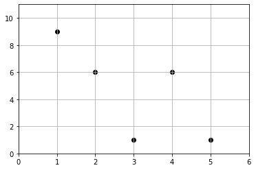

```python
## 範例 - 設定軸距

import matplotlib.pyplot as plt
import random

xcoor = [1, 2, 3, 4, 5]
ycoor = [random.randint(1, 10) for i in range(5)]
print(ycoor)
plt.scatter(xcoor, ycoor, c="k")
plt.axis([0, 6, 0, 11])
plt.grid()
plt.show()
```

## 練習

```
請產生1000個點分別為
[1000平方、999的平方、998的平方...1的平方]
並對這1000個點繪製散步圖
請將顏色設定為黃色
```

## 綜合應用 - 三角函數(波形繪製)

```
正弦 sin
    numpy.sin(弧度)   #sin值

    numpy.deg2rad(角度)  #角度轉換弧度
```

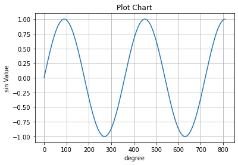

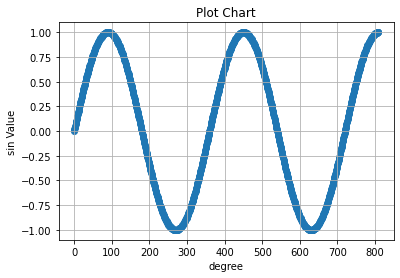

```python
import numpy as np
import matplotlib.pyplot as plt

xcoor = [i for i in range(810)]
ycoor = [np.sin(np.deg2rad(i)) for i in range(810)]
plt.plot(xcoor, ycoor)
plt.title('Plot Chart')
plt.xlabel('degree')
plt.ylabel('sin Value')
plt.grid()
plt.show()
plt.scatter(xcoor, ycoor)
plt.title('Plot Chart')
plt.xlabel('degree')
plt.ylabel('sin Value')
plt.grid()
plt.show()
```